# Facebook Stock Analysis

## CMSC320

```r
#loading in libraries
library(tidyverse)
library(dplyr)

library(rvest)
library(tidyr)
library(stringr)

library(ggplot2)
library(broom)
library(tree)
library(randomForest)
```

## Can we predict the future of a stock and how to maximize profit from it?

Using R, we will analyze Facebook Stock data and seek to answer this question!

This data is taken from the NASDAQ website. This dataset I am working with includes Facebook’s stock data for the past 3 years.

## Data Curation, Parsing, and Management

Let’s then load in the data using the tidyverse library. You can learn more about how to use tidyverse at https://www.tidyverse.org if you need more clarification!

Note, I include “stringsAsFactors=FALSE” inside the read.csv call to make sure the columns are not passed as factors. This lets us tidy data easier!

```r
fb_df <- read.csv("HistoricalQuotes.csv", stringsAsFactors=FALSE) #reading in the csv dataset file
fb_df %>%
  as_data_frame() #using as_data_frame() so it doesn't print out the entire frame
```

```
## # A tibble: 756 x 6
##    date      close   volume  open  high   low
##    <chr>     <dbl>    <int> <dbl> <dbl> <dbl>
##  1 5/9/2018    183 23266280   180   183   179
##  2 5/8/2018    179 15482580   178   179   177
##  3 5/7/2018    178 18302910   177   180   177
##  4 5/4/2018    177 17668270   173   177   173
##  5 5/3/2018    174 23908500   175   176   172
##  6 5/2/2018    176 29812020   174   178   174
##  7 5/1/2018    174 26001150   172   174   170
##  8 4/30/2018   172 20662060   174   176   172
##  9 4/27/2018   174 29773640   177   177   173
## 10 4/26/2018   174 77391810   173   176   171
## # ... with 746 more rows
```

Above, you can see the dataset. Just looking at it, you can see it has 6 columns and 756 rows. If you may be wondering why some dates are missing (such as 4/28/2018), it is because the stock market is not open on the weekends!

When looking at the data set, we can see that some column names aren’t that descriptive - someone who doesn’t know about stocks may have a hard time understanding what these numbers mean.

Let’s rename these columns using the rename function and also reorder the columns in a more logical sense using the select function!

```r
fb_df_updated <- fb_df %>%
  rename(Closing_Price = close,
         Volume_of_Shares_Traded = volume,
         Opening_Price = open) %>% #renamed columns
  select(date, Volume_of_Shares_Traded, Opening_Price, Closing_Price, high, low) %>% #only selecting certain columns
  as_data_frame()
fb_df_updated
```

```
## # A tibble: 756 x 6
##    date      Volume_of_Shares_Tra~ Opening_Price Closing_Price  high   low
##    <chr>                     <int>         <dbl>         <dbl> <dbl> <dbl>
##  1 5/9/2018               23266280           180           183   183   179
##  2 5/8/2018               15482580           178           179   179   177
##  3 5/7/2018               18302910           177           178   180   177
##  4 5/4/2018               17668270           173           177   177   173
##  5 5/3/2018               23908500           175           174   176   172
##  6 5/2/2018               29812020           174           176   178   174
##  7 5/1/2018               26001150           172           174   174   170
##  8 4/30/2018              20662060           174           172   176   172
##  9 4/27/2018              29773640           177           174   177   173
## 10 4/26/2018              77391810           173           174   176   171
## # ... with 746 more rows
```

Let’s split up this date into months, days, and years through the separate method. We should also convert these numbers into integers for later analysis using the type_convert method - this parses the character attributes into integers.

```r
fb_df_dates <- fb_df_updated %>%
  mutate(Date = date) %>%
  separate(date, c("Month", "Day", "Year"), "/") %>% #separating the date by "/"
  type_convert(cols(Month=col_integer(), Day=col_integer(), Year= col_integer() )) %>% #converting these new columns to integers
  mutate(Date=as.Date(Date, format = "%m/%d/%Y")) %>% #converting Date to a date object
  select(Date, Month, Day, Year, Volume_of_Shares_Traded, Opening_Price, Closing_Price, high, low) %>%
  as_data_frame()

fb_df_dates
```

```
## # A tibble: 756 x 9
##    Date       Month   Day  Year Volume_of_Shares_Traded Opening_Price
##    <date>     <int> <int> <int>                   <int>         <dbl>
##  1 2018-05-09     5     9  2018                23266280           180
##  2 2018-05-08     5     8  2018                15482580           178
##  3 2018-05-07     5     7  2018                18302910           177
##  4 2018-05-04     5     4  2018                17668270           173
##  5 2018-05-03     5     3  2018                23908500           175
##  6 2018-05-02     5     2  2018                29812020           174
##  7 2018-05-01     5     1  2018                26001150           172
##  8 2018-04-30     4    30  2018                20662060           174
##  9 2018-04-27     4    27  2018                29773640           177
## 10 2018-04-26     4    26  2018                77391810           173
## # ... with 746 more rows, and 3 more variables: Closing_Price <dbl>,
## #   high <dbl>, low <dbl>
```

Since we now have a nice data frame, let’s begin the analysis with a plot of how the stock price changes across years using ggplot2. You can learn more about ggplot2 here: http://ggplot2.org/ !

Closing Price is the price that is displayed since it is the indication of how well or how poorly the stock performed during the day. Because of this, we can get rid of columns that are not as important in the data frame such as high and low.

```r
fb_df_cleaned <- fb_df_dates %>%
  select(Date, Month, Day, Year, Volume_of_Shares_Traded, Opening_Price, Closing_Price) %>% #dropping low and high columns
  as_data_frame()

fb_df_cleaned
```

```
## # A tibble: 756 x 7
##    Date       Month   Day  Year Volume_of_Shares_Traded Opening_Price
##    <date>     <int> <int> <int>                   <int>         <dbl>
##  1 2018-05-09     5     9  2018                23266280           180
##  2 2018-05-08     5     8  2018                15482580           178
##  3 2018-05-07     5     7  2018                18302910           177
##  4 2018-05-04     5     4  2018                17668270           173
##  5 2018-05-03     5     3  2018                23908500           175
##  6 2018-05-02     5     2  2018                29812020           174
##  7 2018-05-01     5     1  2018                26001150           172
##  8 2018-04-30     4    30  2018                20662060           174
##  9 2018-04-27     4    27  2018                29773640           177
## 10 2018-04-26     4    26  2018                77391810           173
## # ... with 746 more rows, and 1 more variable: Closing_Price <dbl>
```

Now let’s plot the graph described before:

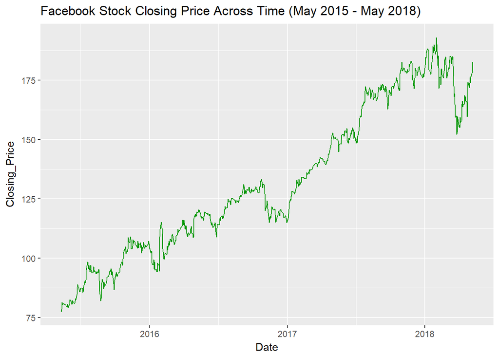

```r
fb_df_cleaned %>%
  ggplot(aes(x=Date, y=Closing_Price)) + #x is Date and y is Closing_Price
  geom_line(color = "#009700") + #coloring the line
  labs(title="Facebook Stock Closing Price Across Time (May 2015 - May 2018)")
```

I also colored the line green using color = “#009700” inside geom_line(), so it looks like the stock graph on google when you search “fb stock”!

Since there is now a basic understanding of stocks and how ggplot2 works, let’s head a bit deeper into Exploratory Data Analysis.

## Exploratory Data Analysis

Similar to the plot before, using a certain type of plot requires you to do ggplot(…) + geom_X() where X is a type of plot. This applies to many types of plots made using ggplot. Let’s trying doing a scatter plot! In this case, we are going to use geom_point() and add in a regression line!

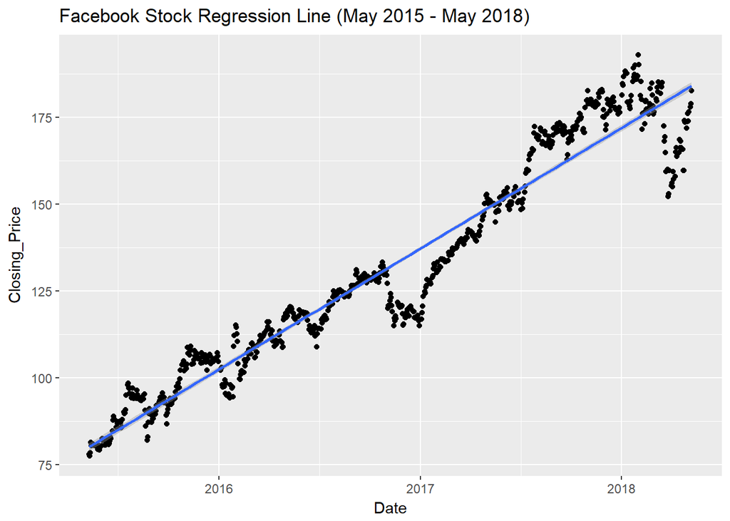

```r
fb_df_cleaned %>%
  ggplot(aes(x=Date, y=Closing_Price)) +
  geom_point() +
  labs(title="Facebook Stock Regression Line (May 2015 - May 2018)") +
  geom_smooth(method=lm) #showing regression line
```

This regression line helps to indicate the relationship between date and closing price.

Let’s see how closing price correlates to opening price

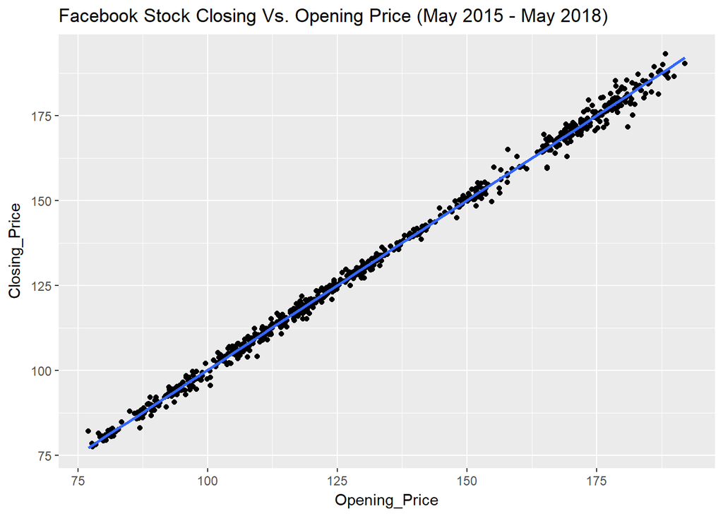

```r
fb_df_cleaned %>%
  ggplot(aes(x=Opening_Price, y=Closing_Price)) +
  geom_point() +
  labs(title="Facebook Stock Closing Vs. Opening Price (May 2015 - May 2018)") +
  geom_smooth(method=lm)
```

We can also quickly analyze central tendencies, spread, and outliers of the data using a boxplot.

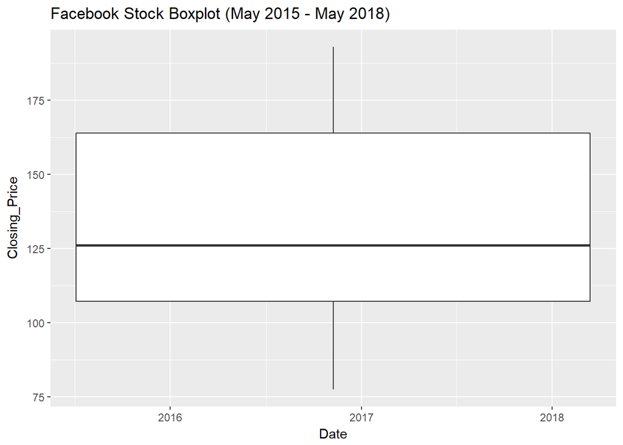

```r
fb_df_cleaned %>%
  ggplot(aes(x=Date, y=Closing_Price)) +
  geom_boxplot() + #type of plot is boxplot
  labs(title="Facebook Stock Boxplot (May 2015 - May 2018)")
```

However, this only shows the boxplot for all years grouped into one. Suppose we want to see the boxplot for each year? We can do this by using a group in the aes (aesthetic) for year. This is where the separation of the date we did earlier comes into play!

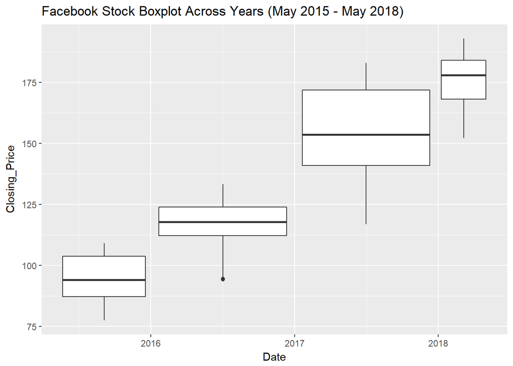

```r
fb_df_cleaned %>%
  ggplot(aes(x=Date, y=Closing_Price, group=Year)) + #grouping data by year
  geom_boxplot() +
  labs(title="Facebook Stock Boxplot Across Years (May 2015 - May 2018)")
```

Now we can see the measures of central tendencies, spread, and outliers of the boxplot for all years! Through exploratory data analysis, we can say that the median and max have increased every year in a linear trend.

But say we want to know more about this data set. What can we figure out using the data we have?

Since people are trying to make money with stocks, they always want to know when a good time to sell the stock is. Using our data, we can find that out.

To solve this, I can find out how the average Volume traded correlates to the average closing price across years.

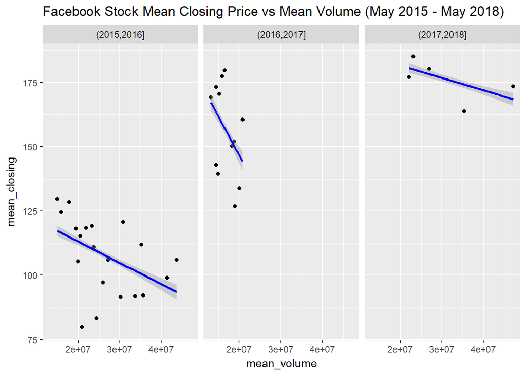

```r
fb_df_cleaned %>%
  mutate(year_cut = cut(Year, breaks=3)) %>% #cutting into 3 periods
  group_by(year_cut, Year, Month) %>%
  mutate(mean_closing = mean(Closing_Price)) %>% #getting averages
  mutate(mean_volume = mean(Volume_of_Shares_Traded)) %>%
  ggplot(aes(x=mean_volume, y=mean_closing)) +
  facet_grid(. ~ year_cut) + #displaying each time period
  geom_point() +
  geom_smooth(method=lm, color="blue") +
  labs(title="Facebook Stock Mean Closing Price vs Mean Volume (May 2015 - May 2018)")
```

By using a cut across 3 years, I can see how the average Closing Price relates to the average volume traded. In 2015 to 2016, it seems like as volume traded went up, the average closing price went down. It also follows a similar trend in the other 2 time periods of 2016 to 2017 and 2017 to 2018.

Using this data, one can be wary of the market. He or she would know that as soon as the volume starts increasing, the closing price typically goes down so when this happens, it is time to sell the stock.

Let’s see how this varies for opening price!

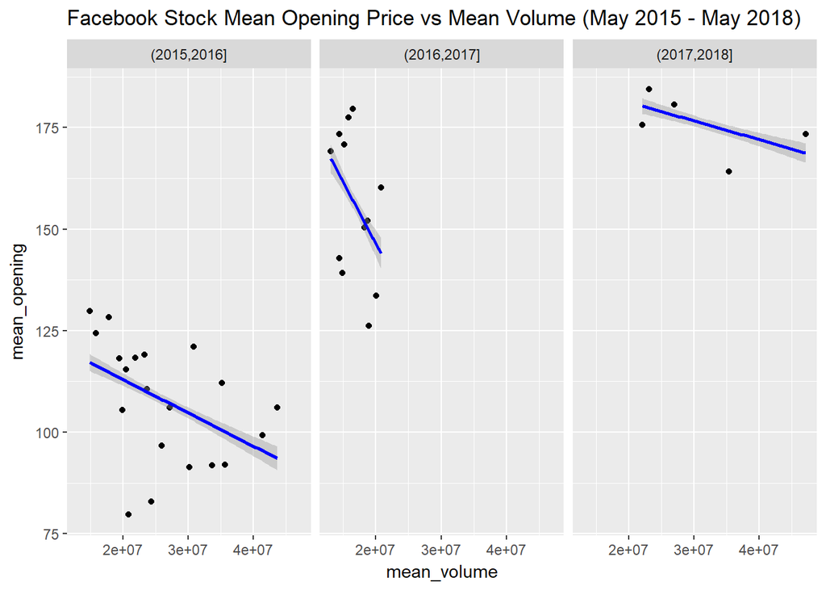

```r
fb_df_cleaned %>%
  mutate(year_cut = cut(Year, breaks=3)) %>% #cutting into 3 periods
  group_by(year_cut, Year, Month) %>%
  mutate(mean_opening = mean(Opening_Price)) %>% #getting averages
  mutate(mean_volume = mean(Volume_of_Shares_Traded)) %>%
  ggplot(aes(x=mean_volume, y=mean_opening)) +
  facet_grid(. ~ year_cut) + #displaying each time period
  geom_point() +
  geom_smooth(method=lm, color="blue") +
  labs(title="Facebook Stock Mean Opening Price vs Mean Volume (May 2015 - May 2018)")
```

As you can see, it looks almost exactly the same so prices throughout the day have not differed much at all!